# Investimento dos Partidos em Parlamentares

### Resumo

Analisamos os **valores doados pelos partidos para os Deputados Federais e Senadores** nas Eleições de 2018. Identificamos e comparamos parlamentares de um partido e entre partidos.

## Deputados

### Sobre os dados

Os dados das receitas dos Deputados Federais, enquanto candidatos nas Eleições de 2018, foram obtidos do **TSE** (Tribunal Superior Eleitoral) e estão disponíveis [aqui](http://www.tse.jus.br/eleicoes/estatisticas/repositorio-de-dados-eleitorais-1/repositorio-de-dados-eleitorais). Filtramos para considerar apenas deputados que mantiveram seus partidos desde a eleição de 2018. Consideramos todos os valores doados pelo partido independente do diretório (nacional ou estadual).

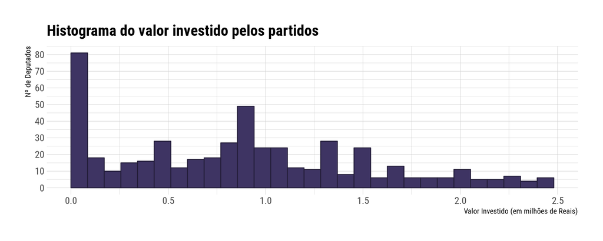

Olhar o valor absoluto doado torna-se insuficiente uma vez que os partidos possuem uma diferente quantidade de dinheiro e de candidatos para distribuir este dinheiro. **Calculamos a proporção de quanto o deputado recebeu do partido com relação a todo o valor investido pelo partido em todos os candidatos ao mesmo cargo** (eleitos e não eleitos).

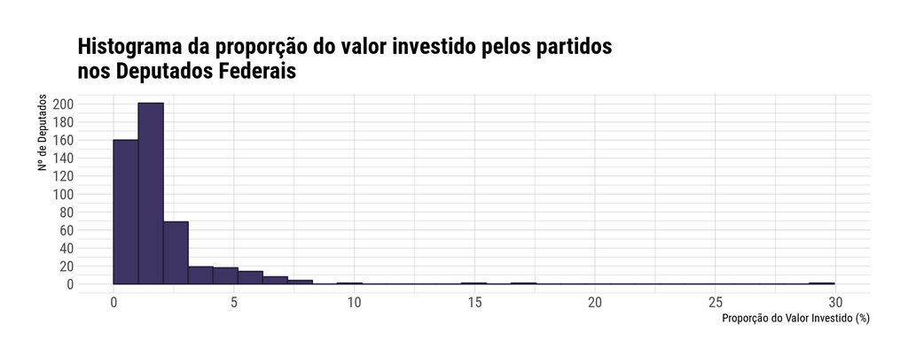

Fica claro que quando olhamos para a proporção do valor recebido com relação a todos os demais candidatos do partido, poucos são os deputados que possuem mais de 10% do total investido pelo partido. Abaixo é possível conferir alguns nomes.

### Quem teve maior investimento absoluto?

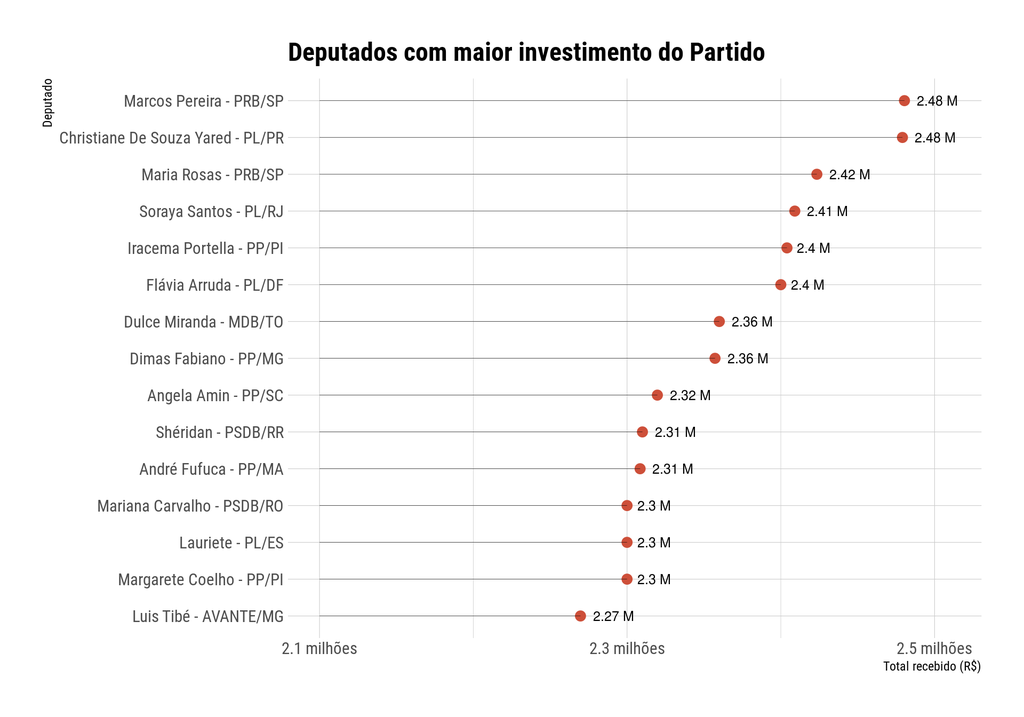

### Quem teve maior investimento proporcional?

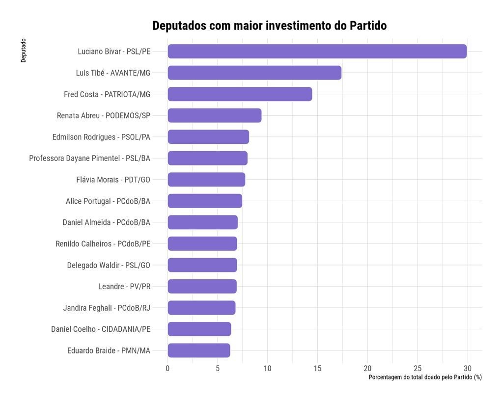

O Deputado Federal com maior investimento proporcional do partido é **Luciano Bivar do PSL/PE** com quase 30%. Ele também é **presidente do PSL** (na data de análise desses dados 29/07/2019).

### Investimento por Partido

A seguir iremos olhar todos os deputados federais atuais a partir de seus partidos. Deixamos de fora partidos com menos de 5 membros.

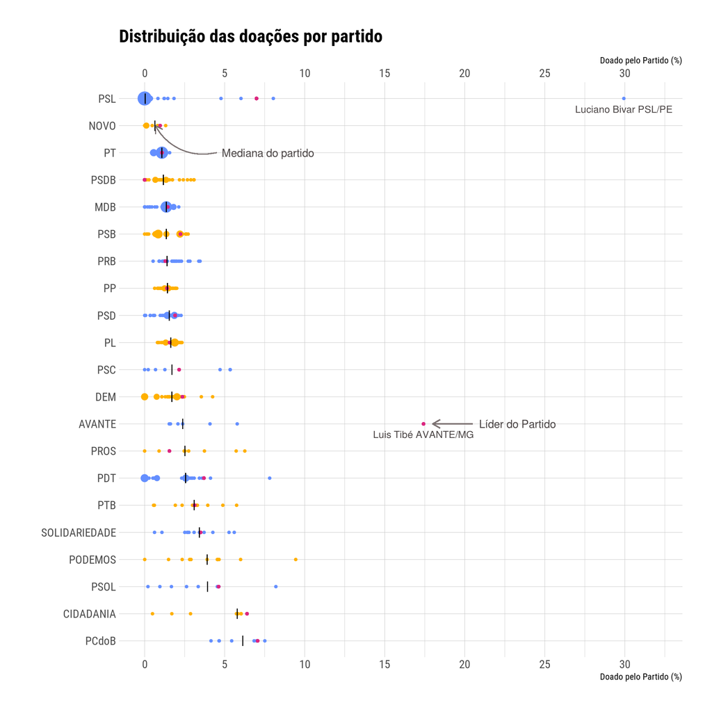

Os partidos estão ordenados de acordo com a mediana do valor proporcional de seus membros. Estão identificados no gráfico os parlamentares com mais de 15% recebidos do total do partido. É possível afirmar que esses deputados possuem uma importância elevada para o partido uma vez que houve um investimento alto na candidatura dos mesmos. Em rosa estão apontados os líderes dos partidos na Câmara (até a data atual de 29/07/2019). A mediana do partido é apontada pela marca “|”.

### Relação com Mandatos

O gráfico a seguir busca responder o questionamento de se os deputados mais experientes na câmara são aqueles que mais recebem investimento dos partidos.

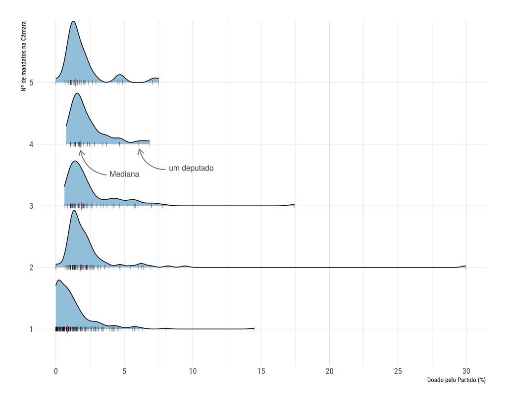

Olhando o número de mandatos dos atuais Deputados Federais, o gráfico acima mostra que não podemos apontar uma relação direta entre o número de mandatos e a proporção da doação do partido. No entanto, é possível observar que deputados com mais de 1 mandato geralmente recebem mais do que os que estão em seu primeiro mandato. Isso é mostrado pelo valor da mediana apontado na visualização.

### Relação com Aderência ao Partido

Analisamos todas as votações nominais realizadas no plenário da Câmara no primeiro semestre de 2019 e calculamos quantas vezes um deputado seguiu a orientação explícita de seu partido ou não. Dizemos que o deputado é 100% aderente se seguiu seu partido em todas as vezes que votou e 0% caso não tiver seguido.

Cruzamos esses dados de aderência com o investimento proporcional dos partidos nos Deputados Federais e visualizamos a seguir.

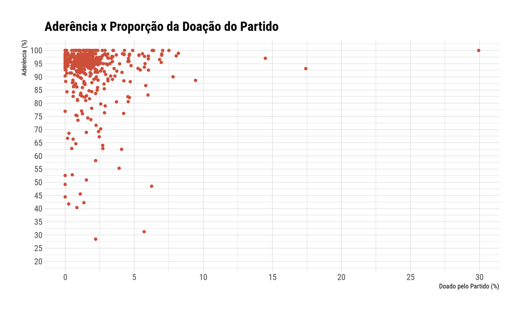

Não é possível afirmar uma relação direta entre a obediência/aderência ao partido e o investimento proporcional recebido pelo partido.

### Investimento por Gênero

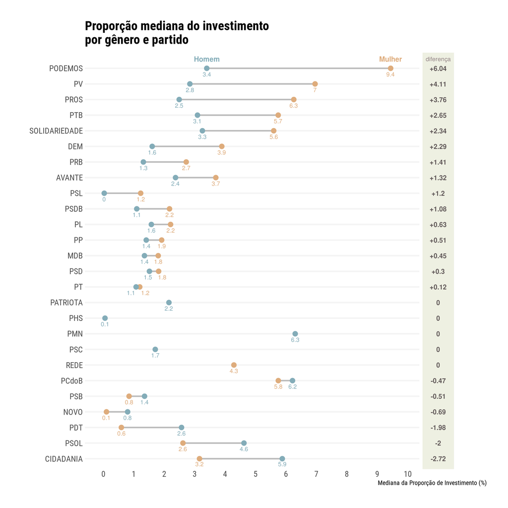

Pela visualização é possível identificar a diferença entre as medianas da proporção de investimento do partido considerando o gênero do Parlamentar. É possível saber quais partidos doaram mais para mulheres do que para homens nas eleições de 2018.

## Senadores

Realizamos uma análise semelhante para o Senadores. Coletamos dados de 45 senadores dos 81 atuais. Nas eleições de 2018, 2 senadores de cada unidade federativa foram eleitos para um mandato de 8 anos.

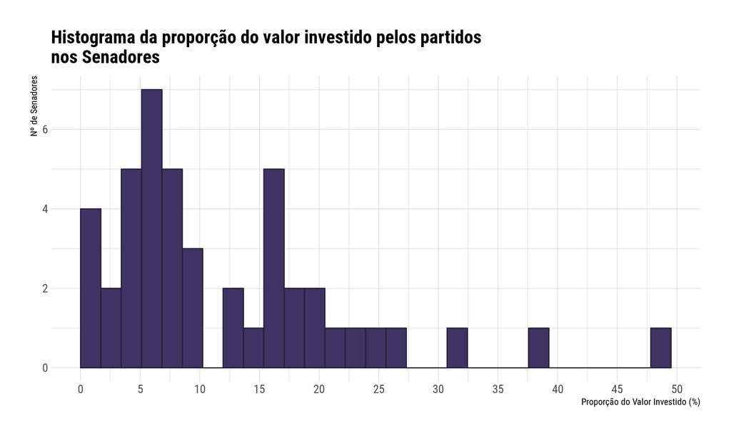

A maioria dos senadores recebeu 30% ou menos do investimento total dos partidos para este cargo. Poucos são os casos de senadores que receberam mais do que esse valor.

### Quem teve maior investimento absoluto?

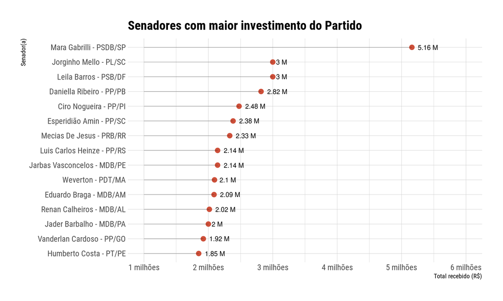

### Quem teve maior investimento proporcional?

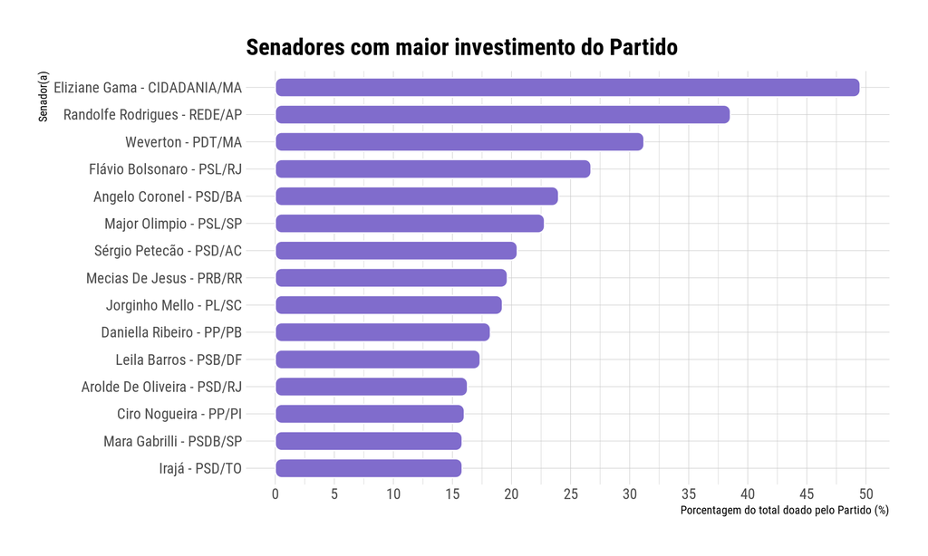

### Investimento por partido

Em seguida, vamos analisar por partido como o valor de doação foi distribuído entre os deputados.

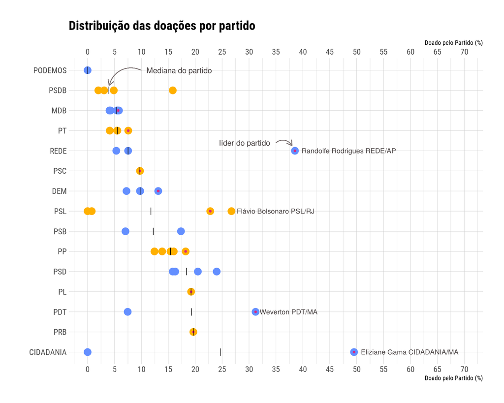

Nas eleições para o cargo de Senador há menos candidatos por partido quando comparamos com a eleição a Deputado Federal. Como consequência temos uma porcentagem maior distribuída para o senadores dentro de um partido. As cores na visualização apenas ajudam na diferenciação de partidos próximos no gráfico.

### Relação com Mandatos

O gráfico a seguir busca responder o questionamento de se os senadores mais experientes no Senado são aqueles que mais recebem investimento dos partidos. Contamos um mandato quando um senador assume seu cargo por algum período durante alguma das duas legislaturas do mandato (8 anos). Usamos os [Dados Abertos](https://www12.senado.leg.br/dados-abertos) do Senado para capturar informação dos mandatos.

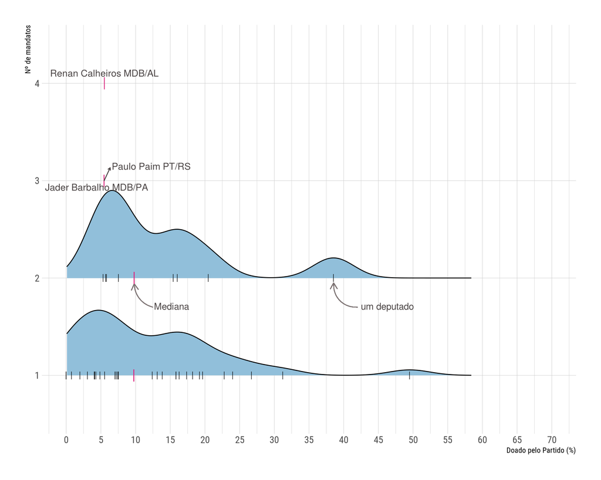

Nota-se que a mediana do grupo de deputados que estão no segundo mandato é bem parecida com a mediana do grupo que está no primeiro mandato. Ou seja, o investimento do partido não cresceu, considerando a mediana geral, em relação a experiência do parlamentar no Senado.

### Investimento por Gênero

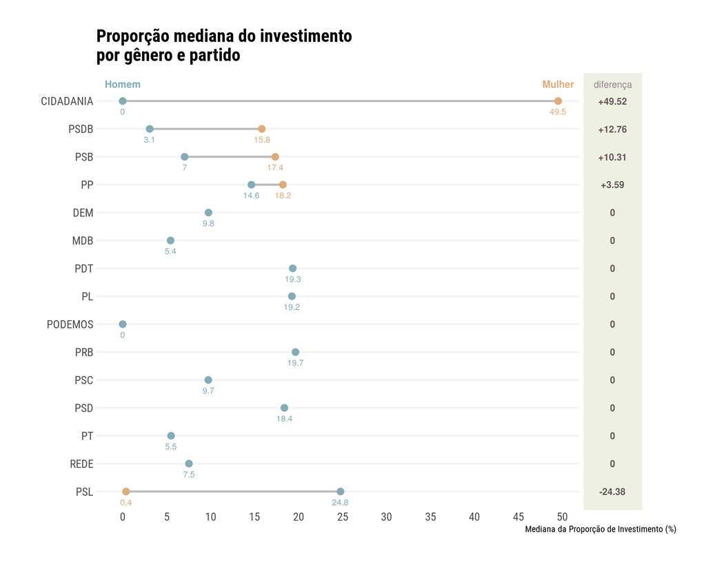

Pela visualização é possível identificar a diferença entre as medianas da proporção de investimento do partido considerando o gênero do Parlamentar. É possível saber quais partidos doaram mais para mulheres do que para homens nas eleições de 2018.

## Mais dados

Para descobrir sobre outros parlamentares que não foram citados nessa análise use as tabelas abaixo.

### Deputados

| Nome | Partido | UF | Total recebido | Doação pelo Partido (%) | Nº de mandatos | Aderência ao partido (%) |
| --- | --- | --- | --- | --- | --- | --- |
| Luciano Bivar - PSL/PE | PSL | PE | 1.8 milhões | 29.9389208092858 | 2 | 100 |
| Luis Tibé - AVANTE/MG | AVANTE | MG | 2.27 milhões | 17.4242515189502 | 3 | 93.1 |
| Fred Costa - PATRIOTA/MG | PATRIOTA | MG | 1.06 milhões | 14.4929068075604 | 1 | 97.01 |
| Renata Abreu - PODEMOS/SP | PODEMOS | SP | 2.03 milhões | 9.43915602373452 | 2 | 88.64 |
| Edmilson Rodrigues - PSOL/PA | PSOL | PA | 538.95 mil | 8.19898267909102 | 2 | 98.92 |
| Professora Dayane Pimentel - PSL/BA | PSL | BA | 483.4 mil | 8.04026351067152 | 1 | 97.92 |
| Flávia Morais - PDT/GO | PDT | GO | 1.52 milhões | 7.81144717640229 | 3 | 90 |
| Alice Portugal - PCdoB/BA | PCdoB | BA | 1.45 milhões | 7.50893825196216 | 5 | 100 |
| Daniel Almeida - PCdoB/BA | PCdoB | BA | 1.36 milhões | 7.06029782454236 | 5 | 100 |
| Renildo Calheiros - PCdoB/PE | PCdoB | PE | 1.35 milhões | 6.99312627622142 | 3 | 98.68 |

[output cut: 503 more lines]

### Senadores

| Nome | Partido | UF | Total recebido | Doação pelo Partido (%) | Nº de mandatos |
| --- | --- | --- | --- | --- | --- |
| Eliziane Gama - CIDADANIA/MA | CIDADANIA | MA | 1.27 milhões | 49.5170950285733 | 1 |
| Randolfe Rodrigues - REDE/AP | REDE | AP | 1.02 milhões | 38.5341147555562 | 2 |
| Weverton - PDT/MA | PDT | MA | 2.1 milhões | 31.2192723697148 | 1 |
| Flávio Bolsonaro - PSL/RJ | PSL | RJ | 209.81 mil | 26.7355400029364 | 1 |
| Angelo Coronel - PSD/BA | PSD | BA | 1.4 milhões | 23.991239824981 | 1 |
| Major Olimpio - PSL/SP | PSL | SP | 178.9 mil | 22.7970212959971 | 1 |
| Sérgio Petecão - PSD/AC | PSD | AC | 1.2 milhões | 20.4931285559002 | 2 |
| Mecias De Jesus - PRB/RR | PRB | RR | 2.33 milhões | 19.6542411262953 | 1 |
| Jorginho Mello - PL/SC | PL | SC | 3 milhões | 19.2376680064984 | 1 |
| Daniella Ribeiro - PP/PB | PP | PB | 2.82 milhões | 18.2201311508787 | 1 |

[output cut: 71 more lines]